# Практика · Перенос навчання

> Лекція: lecture.html · Тест: quiz.html · Домашнє завдання: homework.html

> ⏱ Зошит навчає **понад пʼятдесят** мереж: дві великі джерельні по 1500 прикладів і решту маленьких, від 12 до 240 прикладів. Заміряно на чотирьох ядрах без відеокарти: **півтори хвилини** на вільній машині й до чотирьох на завантаженій. Сам рахунок іде в один потік — так швидше, див. нижче.

У лекції ми стверджували чотири речі. Тут ти отримаєш кожну з них числом.

**Мережа не потрібна:** датасет ми малюємо самі, формулами. Передтренованих ваг із ImageNet тут немає свідомо — вони важать 44,7 МБ і тягнуться з інтернету.

```python
import time
import copy
import numpy as np
import torch
import torch.nn as nn

# зерна фіксуємо на самому початку: без них числа нижче не збіжаться з лекцією
torch.manual_seed(0)
rng = np.random.default_rng(42)

# один потік, а не чотири. Мережа тут крихітна, і на батчі з восьми зображень
# чотири потоки більше часу домовляються між собою, ніж рахують: заміряно
# 34,5 мс на крок в один потік проти 1226 мс у чотири на завантаженій машині.
torch.set_num_threads(1)

notebook_started = time.perf_counter()

print("torch      :", torch.__version__)
print("numpy      :", np.__version__)
print("потоків CPU:", torch.get_num_threads())
```

```
torch      : 2.10.0+cpu
numpy      : 2.5.1
потоків CPU: 1
```

## 1 · Дві задачі з одного світу

Переносити можна лише тоді, коли є **звідки** й **куди**. Тому задач у нас дві.

- **Джерельна задача** — три фігури: коло, квадрат, ромб. Даних багато: 1500 прикладів.
- **Цільова задача** — три **інші** фігури: кільце, хрест, трикутник. Даних мало, і саме це ми будемо міняти: від 12 до 240 прикладів.

Класи не перетинаються. Модель, навчена на колі й квадраті, ніколи не бачила хреста — переносяться не відповіді, а вміння дивитися.

```python
SHAPE_NAMES = ["коло", "квадрат", "ромб", "кільце", "хрест", "трикутник"]
SOURCE_KINDS = [0, 1, 2]        # коло, квадрат, ромб
TARGET_KINDS = [3, 4, 5]        # кільце, хрест, трикутник


def draw_shape(kind, rng, size=28, jitter=5, noise=0.60):
    """Малює одну фігуру заданого класу як масив 28×28 зі значеннями 0..1.

    Шум великий (σ=0.6) і зсув теж (±5 пікселів) — і це навмисно. На чистих
    фігурах задача розвʼязується з дванадцяти прикладів, і жодної різниці між
    способами навчання не видно: усі дають одиницю.
    """
    image = np.zeros((size, size), dtype=np.float32)
    # центр зсуваємо на кілька пікселів, щоб мережа не завчила одне положення
    center_y = size / 2 + rng.integers(-jitter, jitter + 1)
    center_x = size / 2 + rng.integers(-jitter, jitter + 1)
    radius = rng.integers(7, 10)

    # відстані кожного пікселя від центра — з них складаються всі шість фігур
    yy, xx = np.mgrid[0:size, 0:size]
    dy, dx = yy - center_y, xx - center_x

    if kind == 0:                                    # коло
        image[dy * dy + dx * dx <= radius * radius] = 1.0
    elif kind == 1:                                  # квадрат
        image[(np.abs(dy) <= radius * 0.85) & (np.abs(dx) <= radius * 0.85)] = 1.0
    elif kind == 2:                                  # ромб
        image[np.abs(dy) + np.abs(dx) <= radius] = 1.0
    elif kind == 3:                                  # кільце
        distance = dy * dy + dx * dx
        image[(distance <= radius * radius) & (distance >= (radius - 3) ** 2)] = 1.0
    elif kind == 4:                                  # хрест
        image[(np.abs(dy) <= 2) & (np.abs(dx) <= radius)] = 1.0
        image[(np.abs(dx) <= 2) & (np.abs(dy) <= radius)] = 1.0
    else:                                            # трикутник
        image[(dy >= -radius * 0.8) & (dy <= radius * 0.8)
              & (np.abs(dx) <= (dy + radius * 0.8) * 0.6)] = 1.0

    image += rng.normal(0, noise, image.shape).astype(np.float32)
    return np.clip(image, 0, 1)


def make_dataset(count, kinds, rng):
    """Повертає (count, 1, 28, 28) і (count,). Мітки — 0..len(kinds)-1, порівну."""
    images = np.zeros((count, 1, 28, 28), dtype=np.float32)
    labels = np.zeros(count, dtype=np.int64)
    for i in range(count):
        slot = i % len(kinds)                  # рівно по третині кожного класу
        images[i, 0] = draw_shape(kinds[slot], rng)
        labels[i] = slot
    return torch.from_numpy(images), torch.from_numpy(labels)


source_x, source_y = make_dataset(1500, SOURCE_KINDS, rng)
target_pool_x, target_pool_y = make_dataset(240, TARGET_KINDS, rng)
test_x, test_y = make_dataset(300, TARGET_KINDS, rng)

print("джерело      :", tuple(source_x.shape), "мітки", sorted(set(source_y.tolist())))
print("цільовий пул :", tuple(target_pool_x.shape))
print("цільовий тест:", tuple(test_x.shape))
```

```
джерело      : (1500, 1, 28, 28) мітки [0, 1, 2]
цільовий пул : (240, 1, 28, 28)
цільовий тест: (300, 1, 28, 28)
```

Подивимось на обидві трійки очима. Верхній рядок — джерело, нижній — ціль. Фігури різні, але світ один: біла фігура на чорному тлі, трохи зсунута, з шумом.

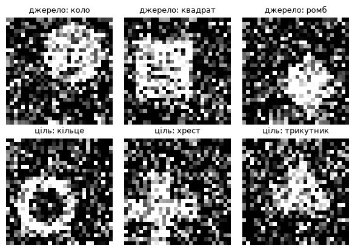

```
три класи в джерелі й три ІНШІ класи в цілі — спільних відповідей немає
```

```python
import matplotlib.pyplot as plt

figure, axes = plt.subplots(2, 3, figsize=(6, 4.2))
for slot in range(3):
    axes[0, slot].imshow(source_x[slot, 0], cmap="gray")
    axes[0, slot].set_title("джерело: " + SHAPE_NAMES[SOURCE_KINDS[slot]], fontsize=9)
    axes[1, slot].imshow(target_pool_x[slot, 0], cmap="gray")
    axes[1, slot].set_title("ціль: " + SHAPE_NAMES[TARGET_KINDS[slot]], fontsize=9)
    axes[0, slot].axis("off")
    axes[1, slot].axis("off")
plt.tight_layout()
plt.show()
print("три класи в джерелі й три ІНШІ класи в цілі — спільних відповідей немає")
```

## 2 · Мережа: тіло і голова

Мережа з теми 09, розділена на дві частини **явно**, окремими полями:

- **тіло** (`body`) — три блоки `Conv → ReLU → Pool`. Воно перетворює зображення 28×28 на 288 чисел: 32 канали по 3×3. Це і є представлення.
- **голова** (`head`) — `Flatten` і два повнозвʼязні шари. Вона ухвалює рішення.

Перенос — це буквально «лишити `body`, замінити `head`». Щоб так можна було зробити, розділення треба закласти в код заздалегідь.

```python
def conv_block(in_channels, out_channels):
    """Один типовий блок: Conv → ReLU → Pool (порядок з теми 09)."""
    return nn.Sequential(
        nn.Conv2d(in_channels, out_channels, kernel_size=3, padding=1),
        nn.ReLU(),
        nn.MaxPool2d(2),
    )


def make_head(n_classes=3):
    """Нова голова: 288 чисел від тіла → 64 → кількість класів."""
    return nn.Sequential(
        nn.Flatten(),
        nn.Linear(32 * 3 * 3, 64),
        nn.ReLU(),
        nn.Linear(64, n_classes),
    )


class ShapeNet(nn.Module):
    """Тіло й голова — окремі поля, щоб голову можна було замінити одним рядком."""

    def __init__(self, n_classes=3):
        super().__init__()
        self.body = nn.Sequential(
            conv_block(1, 8),      # 1×28×28  →  8×14×14
            conv_block(8, 16),     # 8×14×14  → 16×7×7
            conv_block(16, 32),    # 16×7×7   → 32×3×3
        )
        self.head = make_head(n_classes)

    def forward(self, x):
        return self.head(self.body(x))


torch.manual_seed(0)
probe = ShapeNet(3)
body_params = sum(p.numel() for p in probe.body.parameters())
head_params = sum(p.numel() for p in probe.head.parameters())

# ручний рахунок голови: 288×64 ваг + 64 зсуви + 64×3 ваг + 3 зсуви
head_by_hand = 288 * 64 + 64 + 64 * 3 + 3

print("параметрів у тілі  :", body_params)
print("параметрів у голові:", head_params, "  рукою:", head_by_hand)
assert head_params == head_by_hand, "ручний рахунок параметрів голови розійшовся!"
print("✅ збігається")
print()
print("частка голови в мережі: %.1f %%" % (100 * head_params / (body_params + head_params)))
```

```
параметрів у тілі  : 5888
параметрів у голові: 18691   рукою: 18691
✅ збігається

частка голови в мережі: 76.0 %
```

## 3 · Навчаємо джерельну модель

Функція `train` нижче отримує окремий аргумент `params` — список параметрів, які вільно вчитися. Це знадобиться, коли ми заморозимо тіло.

```python
def train(model, x, y, epochs, learning_rate, batch=16, seed=0, params=None):
    """Навчає модель. params=None означає «вчити все, що є в моделі»."""
    torch.manual_seed(seed)                      # порядок батчів теж має бути відтворюваним
    optimizer = torch.optim.Adam(
        params if params is not None else model.parameters(), lr=learning_rate)
    loss_function = nn.CrossEntropyLoss()
    model.train()
    for _ in range(epochs):
        order = torch.randperm(len(x))
        for start in range(0, len(x), batch):
            batch_index = order[start:start + batch]
            optimizer.zero_grad()
            loss = loss_function(model(x[batch_index]), y[batch_index])
            loss.backward()
            optimizer.step()
    return model


@torch.no_grad()
def accuracy(model, x, y):
    """Частка правильних відповідей."""
    model.eval()
    return (model(x).argmax(1) == y).float().mean().item()


torch.manual_seed(0)
source_model = ShapeNet(3)

started = time.perf_counter()
train(source_model, source_x, source_y, epochs=10, learning_rate=1e-3, batch=32, seed=0)
source_seconds = time.perf_counter() - started

print("навчання джерельної моделі: %.1f с" % source_seconds)
print("точність на джерельній задачі: %.3f" % accuracy(source_model, source_x, source_y))
```

```
навчання джерельної моделі: 10.8 с
```

```
точність на джерельній задачі: 0.815
```

## 4 · `state_dict`: як ваги переїжджають між моделями

Ваги моделі в PyTorch — це звичайний словник: імʼя шару → тензор чисел. Він зветься `state_dict`, і саме його зберігають у файл `.pt` або `.pth`. Коли ти пишеш `resnet18(weights="IMAGENET1K_V1")`, бібліотека завантажує з інтернету рівно такий словник і кладе його в порожню модель.

Зробимо те саме руками — щоб механізм перестав бути магією.

```python
weights = source_model.state_dict()

print("ключів у state_dict:", len(weights))
print()
print("%-24s %-20s %8s" % ("імʼя", "форма", "чисел"))
print("-" * 54)
for name, tensor in weights.items():
    print("%-24s %-20s %8d" % (name, tuple(tensor.shape), tensor.numel()))
```

```
ключів у state_dict: 10

імʼя                     форма                   чисел
------------------------------------------------------
body.0.0.weight          (8, 1, 3, 3)               72
body.0.0.bias            (8,)                        8
body.1.0.weight          (16, 8, 3, 3)            1152
body.1.0.bias            (16,)                      16
body.2.0.weight          (32, 16, 3, 3)           4608
body.2.0.bias            (32,)                      32
head.1.weight            (64, 288)               18432
head.1.bias              (64,)                      64
head.3.weight            (3, 64)                   192
head.3.bias              (3,)                        3
```

Тепер збережемо словник у файл і завантажимо його в **іншу**, щойно створену модель. Перевірка проста: ваги в обох мають збігтися до останнього біта, а відповіді на тих самих зображеннях — теж.

```python
torch.save(source_model.state_dict(), "source_weights.pt")

import os
print("файл на диску: %.1f КБ" % (os.path.getsize("source_weights.pt") / 1024))

# нова модель із випадковими вагами — поки вона нічого не вміє
torch.manual_seed(123)
restored = ShapeNet(3)
print("до завантаження, точність на джерелі: %.3f" % accuracy(restored, source_x, source_y))

restored.load_state_dict(torch.load("source_weights.pt", weights_only=True))
print("після завантаження, точність на джерелі: %.3f" % accuracy(restored, source_x, source_y))

# звірка «наше = бібліотечне»: ваги мають збігтися побітово
same = all(torch.equal(a, b) for a, b in
           zip(source_model.state_dict().values(), restored.state_dict().values()))
assert same, "ваги після завантаження розійшлися!"
print("✅ усі", len(weights), "тензорів збіглися побітово")

# зберігаємо копію в памʼяті: далі кожен дослід починається з тих самих ваг
source_state = copy.deepcopy(source_model.state_dict())

os.remove("source_weights.pt")            # файл своє показав, теку лишаємо чистою
print("тимчасовий файл ваг прибрано")
```

```
файл на диску: 100.4 КБ
```

```
до завантаження, точність на джерелі: 0.333
```

```
після завантаження, точність на джерелі: 0.815
✅ усі 10 тензорів збіглися побітово
тимчасовий файл ваг прибрано
```

## 5 · Три способи переносу

Тепер три функції, і всі три відрізняються буквально трьома рядками.

| Спосіб | Що з тілом | Що вчиться |
| --- | --- | --- |
| З нуля | нове випадкове | усе |
| Заморожене тіло | ваги джерела, `requires_grad = False` | лише голова |
| Донавчання | ваги джерела, градієнти дозволені | усе |

Голова в другому й третьому випадку **завжди нова**: стара вміє відповідати «коло / квадрат / ромб», а нам треба «кільце / хрест / трикутник».

```python
def build_from_scratch():
    """Порожня мережа: жодного знання ззовні."""
    return ShapeNet(3)


def build_transferred(state, freeze_body=True, frozen_blocks=3):
    """Мережа з чужим тілом і новою головою.

    frozen_blocks — скільки ПЕРШИХ блоків тіла заморозити (0..3).
    freeze_body=False означає донавчання: тіло чуже, але вільне.
    """
    model = ShapeNet(3)
    model.load_state_dict(state)          # тіло й голова джерела
    model.head = make_head(3)             # стару голову викидаємо, ставимо чисту
    if freeze_body:
        for block_index in range(frozen_blocks):
            for parameter in model.body[block_index].parameters():
                parameter.requires_grad = False
    return model


def trainable(model):
    """Список параметрів, яким дозволено змінюватись."""
    return [p for p in model.parameters() if p.requires_grad]


def run(model, n_examples, epochs, learning_rate, seed=1):
    """Навчає модель на перших n прикладах цілі й повертає точність на тесті."""
    x, y = target_pool_x[:n_examples], target_pool_y[:n_examples]
    train(model, x, y, epochs, learning_rate, batch=8, seed=seed, params=trainable(model))
    return accuracy(model, test_x, test_y)


# скільки чисел навчається в кожному режимі й скільки коштує одне навчання
MODES = [
    ("з нуля", lambda: build_from_scratch(), 3e-3),
    ("заморожене тіло", lambda: build_transferred(source_state), 3e-3),
    ("донавчання", lambda: build_transferred(source_state, freeze_body=False), 5e-4),
]

mode_cost = {}
print("%-18s %12s %10s %10s" % ("спосіб", "навчуваних", "секунд", "точність"))
print("-" * 54)
for name, make_model, learning_rate in MODES:
    torch.manual_seed(1)
    model = make_model()
    free = sum(p.numel() for p in trainable(model))
    started = time.perf_counter()
    score = run(model, 24, epochs=20, learning_rate=learning_rate)
    seconds = time.perf_counter() - started
    mode_cost[name] = (free, seconds, score)
    print("%-18s %12d %10.2f %10.3f" % (name, free, seconds, score))
```

```
спосіб               навчуваних     секунд   точність
------------------------------------------------------
```

```
з нуля                    24579       0.44      0.613
```

```
заморожене тіло           18691       0.31      0.847
```

```
донавчання                24579       0.38      0.770
```

## 6 · Замір 1: розворот на розмірі цільових даних

Головний дослід теми. Беремо 12, 24, 60, 120 і 240 цільових прикладів і в кожній точці навчаємо три моделі: з нуля, із замороженим тілом, із донавчанням. Тест той самий — 300 зображень, яких не бачила жодна з них.

```python
SIZES = (12, 24, 60, 120, 240)
measure_1 = {}

started = time.perf_counter()
for n in SIZES:
    torch.manual_seed(1)
    from_scratch = run(build_from_scratch(), n, epochs=20, learning_rate=3e-3)
    torch.manual_seed(1)
    frozen = run(build_transferred(source_state), n, epochs=20, learning_rate=3e-3)
    torch.manual_seed(1)
    fine_tuned = run(build_transferred(source_state, freeze_body=False), n,
                     epochs=20, learning_rate=5e-4)
    measure_1[n] = (from_scratch, frozen, fine_tuned)

print("%10s %10s %14s %12s" % ("прикладів", "з нуля", "заморожене", "донавчання"))
print("-" * 50)
for n in SIZES:
    a, b, c = measure_1[n]
    lead = "  ← перенос виграє" if b > a else "  ← перенос ПРОГРАЄ"
    print("%10d %10.3f %14.3f %12.3f%s" % (n, a, b, c, lead))
print()
print("рівень випадкового вгадування на трьох класах: 0.333")
print("усього на замір: %.1f с" % (time.perf_counter() - started))
```

```
 прикладів     з нуля     заморожене   донавчання
--------------------------------------------------
        12      0.530          0.667        0.557  ← перенос виграє
        24      0.613          0.847        0.770  ← перенос виграє
        60      0.830          0.947        0.927  ← перенос виграє
       120      0.963          0.967        0.960  ← перенос виграє
       240      0.993          0.970        0.977  ← перенос ПРОГРАЄ

рівень випадкового вгадування на трьох класах: 0.333
усього на замір: 21.8 с
```

Тепер знайдемо **точку розвороту** — найменший розмір вибірки, при якому навчання з нуля вже не гірше за перенос. Це і є практична відповідь на питання «чи брати мені передтреновану модель».

```python
crossover = None
for n in SIZES:
    from_scratch, frozen, _ = measure_1[n]
    if from_scratch >= frozen:
        crossover = n
        break

if crossover is None:
    print("на всіх перевірених розмірах перенос попереду — розворот далі за 120 прикладів")
else:
    print("розворот стався на", crossover, "прикладах")
    before = SIZES[SIZES.index(crossover) - 1]
    print("на %d прикладах: з нуля %.3f проти переносу %.3f" % (before, *measure_1[before][:2]))
    print("на %d прикладах: з нуля %.3f проти переносу %.3f" % (crossover, *measure_1[crossover][:2]))
    print()
    print("висновок: перенос — це ліки від нестачі даних, а не безумовне покращення")
```

```
розворот стався на 240 прикладах
на 120 прикладах: з нуля 0.963 проти переносу 0.967
на 240 прикладах: з нуля 0.993 проти переносу 0.970

висновок: перенос — це ліки від нестачі даних, а не безумовне покращення
```

## 7 · Замір 2: донавчання проти замороженого тіла — чесно

Перевіримо на 24 прикладах, як обидва способи реагують на налаштування.

```python
measure_2 = []

# та сама сітка налаштувань для обох способів — інакше порівняння нечесне
for mode in ("заморожене тіло", "донавчання"):
    for learning_rate in (5e-4, 1e-3, 3e-3):
        for epochs in (20, 40):
            torch.manual_seed(1)
            model = build_transferred(source_state,
                                      freeze_body=(mode == "заморожене тіло"))
            measure_2.append((mode, learning_rate, epochs,
                              run(model, 24, epochs, learning_rate)))

print("%-18s %8s %7s %10s" % ("режим", "lr", "епох", "точність"))
print("-" * 46)
for mode, learning_rate, epochs, score in measure_2:
    print("%-18s %8.0e %7d %10.3f" % (mode, learning_rate, epochs, score))

frozen_scores = [s for m, _, _, s in measure_2 if m == "заморожене тіло"]
tuned_scores = [s for m, _, _, s in measure_2 if m == "донавчання"]
print()
print("заморожене тіло: від %.3f до %.3f, розкид %.3f"
      % (min(frozen_scores), max(frozen_scores), max(frozen_scores) - min(frozen_scores)))
print("донавчання     : від %.3f до %.3f, розкид %.3f"
      % (min(tuned_scores), max(tuned_scores), max(tuned_scores) - min(tuned_scores)))
```

```
режим                    lr    епох   точність
----------------------------------------------
заморожене тіло       5e-04      20      0.783
заморожене тіло       5e-04      40      0.797
заморожене тіло       1e-03      20      0.803
заморожене тіло       1e-03      40      0.847
заморожене тіло       3e-03      20      0.847
заморожене тіло       3e-03      40      0.877
донавчання            5e-04      20      0.770
донавчання            5e-04      40      0.827
донавчання            1e-03      20      0.827
донавчання            1e-03      40      0.860
донавчання            3e-03      20      0.857
донавчання            3e-03      40      0.853

заморожене тіло: від 0.783 до 0.877, розкид 0.093
донавчання     : від 0.770 до 0.860, розкид 0.090
```

До заміру 2 варто додати ще один режим, який радять найчастіше: **спершу голова, потім усе тіло з дуже малим кроком**. Ідея в тому, щоб випадкова голова не встигла зіпсувати чуже тіло великими градієнтами на першому ж кроці.

```python
torch.manual_seed(1)
two_stage = build_transferred(source_state, freeze_body=True)
# етап 1: тіло заморожене, голова швидко наздоганяє
train(two_stage, target_pool_x[:24], target_pool_y[:24], 20, 3e-3, batch=8, seed=1,
      params=trainable(two_stage))
# етап 2: розморожуємо все й ідемо дуже дрібним кроком
for parameter in two_stage.parameters():
    parameter.requires_grad = True
train(two_stage, target_pool_x[:24], target_pool_y[:24], 20, 2e-4, batch=8, seed=101,
      params=trainable(two_stage))

two_stage_score = accuracy(two_stage, test_x, test_y)
print("голова, потім усе тіло (lr=2e-4): %.3f" % two_stage_score)
print("найкраще заморожене тіло        : %.3f" % max(frozen_scores))
print("найкраще донавчання             : %.3f" % max(tuned_scores))
```

```
голова, потім усе тіло (lr=2e-4): 0.850
найкраще заморожене тіло        : 0.877
найкраще донавчання             : 0.860
```

## 8 · Замір 3: що саме переноситься

Тіло має три блоки. Заморозимо різну їх кількість — від нуля (усе вільне) до трьох (усе чуже й нерухоме) — і подивимось, де знання джерела допомагає, а де заважає.

Літературне очікування: **ранні шари універсальні, пізні специфічні**. Тобто перший блок можна брати чужим сміливо, а третій — уже під питанням.

```python
FREEZE_LABELS = {0: "нічого", 1: "перший блок", 2: "перші два", 3: "усе тіло"}
measure_3 = {}

for n in (24, 120):
    for frozen_blocks in (0, 1, 2, 3):
        torch.manual_seed(1)
        model = build_transferred(source_state, freeze_body=True, frozen_blocks=frozen_blocks)
        free = sum(p.numel() for p in trainable(model))
        measure_3[(n, frozen_blocks)] = (run(model, n, epochs=20, learning_rate=3e-3), free)

for n in (24, 120):
    print("цільових прикладів:", n)
    print("%16s %10s %20s" % ("заморожено", "точність", "вільних параметрів"))
    print("-" * 50)
    for frozen_blocks in (0, 1, 2, 3):
        score, free = measure_3[(n, frozen_blocks)]
        print("%16s %10.3f %20d" % (FREEZE_LABELS[frozen_blocks], score, free))
    best = max((0, 1, 2, 3), key=lambda k: measure_3[(n, k)][0])
    print("найкраще: заморозити %s (%.3f)" % (FREEZE_LABELS[best], measure_3[(n, best)][0]))
    print()
```

```
цільових прикладів: 24
      заморожено   точність   вільних параметрів
--------------------------------------------------
          нічого      0.857                24579
     перший блок      0.847                24499
       перші два      0.840                23331
        усе тіло      0.847                18691
найкраще: заморозити нічого (0.857)

цільових прикладів: 120
      заморожено   точність   вільних параметрів
--------------------------------------------------
          нічого      0.957                24579
     перший блок      0.953                24499
       перші два      0.967                23331
        усе тіло      0.967                18691
найкраще: заморозити перші два (0.967)
```

## 9 · Замір 4: коли перенос шкодить

Досі джерело було близьке до цілі: ті самі 28×28, біла фігура на чорному тлі. Тепер візьмемо джерело, максимально **несхоже**: суцільні текстури — горизонтальні смуги, вертикальні смуги й рівномірний шум. Тут немає ні предмета, ні тла, ні контуру. Це наш аналог того, як ImageNet виглядає для рентгенівського знімка.

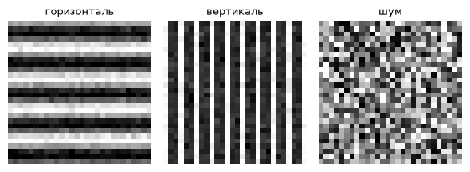

```
далеке джерело: три класи текстур, жодного предмета на тлі
```

```python
def draw_texture(kind, rng, size=28):
    """Текстура на весь кадр: смуги по горизонталі, по вертикалі або чистий шум."""
    yy, xx = np.mgrid[0:size, 0:size]
    phase = rng.uniform(0, 2 * np.pi)
    period = rng.integers(3, 7)
    if kind == 0:
        image = 0.5 + 0.5 * np.sin(2 * np.pi * yy / period + phase)
    elif kind == 1:
        image = 0.5 + 0.5 * np.sin(2 * np.pi * xx / period + phase)
    else:
        image = rng.uniform(0, 1, (size, size))
    image = image.astype(np.float32) + rng.normal(0, 0.05, (size, size)).astype(np.float32)
    return np.clip(image, 0, 1)


def make_texture_dataset(count, rng):
    images = np.zeros((count, 1, 28, 28), dtype=np.float32)
    labels = np.zeros(count, dtype=np.int64)
    for i in range(count):
        images[i, 0] = draw_texture(i % 3, rng)
        labels[i] = i % 3
    return torch.from_numpy(images), torch.from_numpy(labels)


far_x, far_y = make_texture_dataset(1500, rng)

figure, axes = plt.subplots(1, 3, figsize=(6, 2.2))
for kind in range(3):
    axes[kind].imshow(far_x[kind, 0], cmap="gray")
    axes[kind].set_title(["горизонталь", "вертикаль", "шум"][kind], fontsize=9)
    axes[kind].axis("off")
plt.tight_layout()
plt.show()
print("далеке джерело: три класи текстур, жодного предмета на тлі")
```

```python
torch.manual_seed(0)
far_source = ShapeNet(3)
started = time.perf_counter()
train(far_source, far_x, far_y, epochs=10, learning_rate=1e-3, batch=32, seed=0)
print("навчання далекого джерела: %.1f с, точність на ньому %.3f"
      % (time.perf_counter() - started, accuracy(far_source, far_x, far_y)))
far_state = copy.deepcopy(far_source.state_dict())
```

```
навчання далекого джерела: 12.9 с, точність на ньому 1.000
```

```python
measure_4 = {}
for n in SIZES:
    torch.manual_seed(1)
    far = run(build_transferred(far_state), n, 20, 3e-3)
    # «з нуля» і «близьке джерело» вже пораховані в замірі 1 — тими самими зернами
    measure_4[n] = (measure_1[n][0], measure_1[n][1], far)

print("%10s %10s %16s %14s" % ("прикладів", "з нуля", "близьке джерело", "далеке джерело"))
print("-" * 56)
for n in SIZES:
    a, b, c = measure_4[n]
    print("%10d %10.3f %16.3f %14.3f" % (n, a, b, c))

hurt = [n for n in SIZES if measure_4[n][2] < measure_4[n][0]]
print()
if hurt:
    print("далеке джерело гірше за навчання з нуля на розмірах:", hurt)
    print("це і є ціна невдалого переносу: чуже тіло не помагає, а тримає")
else:
    print("навіть далеке джерело не виявилось гіршим за навчання з нуля")
```

```
 прикладів     з нуля  близьке джерело далеке джерело
--------------------------------------------------------
        12      0.530            0.667          0.357
        24      0.613            0.847          0.543
        60      0.830            0.947          0.500
       120      0.963            0.967          0.570
       240      0.993            0.970          0.670

далеке джерело гірше за навчання з нуля на розмірах: [12, 24, 60, 120, 240]
це і є ціна невдалого переносу: чуже тіло не помагає, а тримає
```

## 10 · Перші фільтри: чому їх узагалі можна брати чужими

Тепер подивимось на самі ваги. У першого згорткового шару їх вісім штук по 3×3 — це маленькі шаблони, які мережа прикладає до зображення.

Порівняємо три набори: близьке джерело, далеке джерело й модель, навчену з нуля на **цілі**. Якщо перші фільтри справді універсальні, набори мають бути схожі.

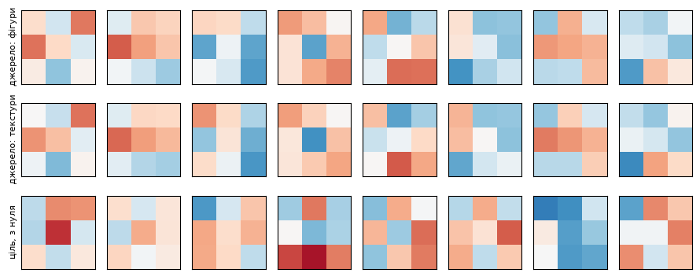

[output not shown]

```python
torch.manual_seed(1)
target_scratch = ShapeNet(3)
train(target_scratch, target_pool_x, target_pool_y, 20, 3e-3, batch=8, seed=1)

near_filters = source_model.body[0][0].weight.detach().numpy()[:, 0]
far_filters = far_source.body[0][0].weight.detach().numpy()[:, 0]
target_filters = target_scratch.body[0][0].weight.detach().numpy()[:, 0]

figure, axes = plt.subplots(3, 8, figsize=(9, 3.8))
rows = [("джерело: фігури", near_filters),
        ("джерело: текстури", far_filters),
        ("ціль, з нуля", target_filters)]
for row, (title, bank) in enumerate(rows):
    for k in range(8):
        axes[row, k].imshow(bank[k], cmap="RdBu", vmin=-0.6, vmax=0.6)
        axes[row, k].set_xticks([])
        axes[row, k].set_yticks([])
    axes[row, 0].set_ylabel(title, fontsize=8)
plt.tight_layout()
plt.show()
print("три банки по вісім ядер 3×3: червоне — додатні ваги, синє — відʼємні")
```

«Схожі на око» — слабкий доказ. Порахуємо схожість числом.

Для кожного ядра цільової моделі знайдемо найсхожіше ядро в чужому банку й візьмемо **косинусну близькість** між ними за модулем. Косинусна близькість — це міра «дивляться в один бік» для двох наборів чисел: 1 — той самий шаблон, 0 — нічого спільного. Модуль тому, що ядро зі зміненим знаком шукає ту саму межу, тільки з іншого боку.

```python
def best_match(bank_a, bank_b):
    """Для кожного ядра з bank_a — найбільша |косинусна близькість| з ядрами bank_b."""
    scores = []
    for i in range(bank_a.shape[0]):
        u = bank_a[i].ravel() - bank_a[i].mean()      # прибираємо середнє: цікавить форма
        best = 0.0
        for j in range(bank_b.shape[0]):
            v = bank_b[j].ravel() - bank_b[j].mean()
            denominator = np.linalg.norm(u) * np.linalg.norm(v)
            if denominator > 1e-9:
                best = max(best, abs(float(u @ v) / denominator))
        scores.append(best)
    return np.array(scores)


random_bank = np.random.default_rng(0).normal(size=near_filters.shape)

print("схожість фільтрів цілі з фільтрами...")
print("  близького джерела : %.3f" % best_match(target_filters, near_filters).mean())
print("  далекого джерела  : %.3f" % best_match(target_filters, far_filters).mean())
print("  випадкового набору: %.3f" % best_match(target_filters, random_bank).mean())
print()
print("випадковий набір — це база порівняння: стільки схожості дає сама лише")
print("розмірність 3×3, без жодного навчання")
```

```
схожість фільтрів цілі з фільтрами...
  близького джерела : 0.616
  далекого джерела  : 0.627
  випадкового набору: 0.578

випадковий набір — це база порівняння: стільки схожості дає сама лише
розмірність 3×3, без жодного навчання
```

```python
def show_bank(title, bank):
    print(title)
    for k in range(bank.shape[0]):
        rows = [" ".join("%5.2f" % v for v in bank[k][r]) for r in range(3)]
        print("  ядро %d: [%s]" % (k, "] [".join(rows)))


show_bank("джерело (фігури):", near_filters)
print()
show_bank("джерело (текстури):", far_filters)
print()
show_bank("ціль, навчена з нуля:", target_filters)
```

```
джерело (фігури):
  ядро 0: [-0.10  0.12 -0.31] [-0.32 -0.12  0.09] [-0.05  0.24 -0.02]
  ядро 1: [ 0.07 -0.16 -0.13] [-0.36 -0.25 -0.17] [ 0.01  0.13  0.22]
  ядро 2: [-0.13 -0.12  0.15] [ 0.32  0.03  0.31] [ 0.01  0.10  0.34]
  ядро 3: [-0.25 -0.18 -0.01] [-0.08  0.32 -0.21] [-0.08 -0.23 -0.30]
  ядро 4: [-0.23  0.28  0.16] [ 0.15 -0.01 -0.16] [ 0.06 -0.33 -0.33]
  ядро 5: [-0.09  0.25  0.24] [-0.07  0.07  0.25] [ 0.36  0.19  0.12]
  ядро 6: [ 0.23 -0.21  0.09] [-0.26 -0.24 -0.21] [ 0.16  0.15 -0.19]
  ядро 7: [ 0.15  0.20  0.02] [ 0.08  0.12  0.25] [ 0.34 -0.18 -0.06]

джерело (текстури):
  ядро 0: [-0.00  0.14 -0.33] [-0.27 -0.18  0.06] [ 0.03  0.26 -0.02]
  ядро 1: [ 0.07 -0.12 -0.12] [-0.34 -0.25 -0.20] [ 0.07  0.18  0.20]
  ядро 2: [-0.27 -0.11  0.18] [ 0.24 -0.08  0.29] [-0.11  0.03  0.35]
  ядро 3: [-0.25 -0.14 -0.01] [-0.07  0.37 -0.17] [-0.07 -0.16 -0.24]
  ядро 4: [-0.18  0.32  0.20] [ 0.13  0.03 -0.12] [-0.01 -0.37 -0.23]
  ядро 5: [-0.20  0.24  0.23] [-0.19 -0.00  0.25] [ 0.31  0.11  0.04]
  ядро 6: [ 0.23 -0.14  0.10] [-0.31 -0.26 -0.21] [ 0.17  0.17 -0.15]
  ядро 7: [ 0.15  0.23 -0.02] [ 0.04  0.11  0.24] [ 0.38 -0.24 -0.11]

ціль, навчена з нуля:
  ядро 0: [ 0.16 -0.28 -0.27] [ 0.18 -0.44  0.11] [-0.11  0.15 -0.06]
  ядро 1: [-0.10  0.10 -0.07] [ 0.16 -0.22 -0.08] [-0.13  0.02 -0.06]
  ядро 2: [ 0.35  0.10 -0.17] [-0.23 -0.11 -0.21] [-0.23 -0.12  0.15]
  ядро 3: [ 0.21 -0.32  0.20] [-0.01  0.27  0.19] [-0.40 -0.49 -0.31]
  ядро 4: [ 0.26 -0.22  0.01] [-0.20  0.22 -0.33] [ 0.24 -0.16 -0.31]
  ядро 5: [ 0.17 -0.22  0.15] [-0.17 -0.09 -0.36] [-0.22  0.15 -0.16]
  ядро 6: [ 0.42  0.37  0.12] [-0.05  0.33  0.23] [ 0.00  0.34  0.31]
  ядро 7: [ 0.32 -0.29 -0.16] [ 0.02  0.02 -0.30] [-0.28  0.12 -0.17]
```

## 11 · Не та нормалізація

Тіло переносять разом із **умовами**, у яких воно навчалось. Найчастіша з них — нормалізація входу. Наша джерельна модель бачила числа в діапазоні 0..1. Подамо їй ті самі зображення, оброблені інакше: `(x - 0.5) / 0.5` (діапазон −1..1), `x * 255` (забули поділити) та `1 - x` (інверсія).

Голова щоразу вчиться заново — тобто в неї є всі шанси пристосуватись.

```python
NORMALIZATIONS = [
    ("та сама, 0..1", lambda t: t),
    ("(x-0.5)/0.5 → -1..1", lambda t: (t - 0.5) / 0.5),
    ("x*255, забули поділити", lambda t: t * 255.0),
    ("1-x, інверсія", lambda t: 1.0 - t),
]

@torch.no_grad()
def silent_share(model, x):
    """Частка нейронів першого блоку, які на цих даних мовчать (ReLU видала нуль)."""
    after_relu = model.body[0][1](model.body[0][0](x))
    return (after_relu == 0).float().mean().item()


measure_6 = {}
print("%-26s %10s %10s %14s" % ("нормалізація цілі", "перенос", "з нуля", "мовчить нейронів"))
print("-" * 64)
for name, transform in NORMALIZATIONS:
    torch.manual_seed(1)
    transferred = build_transferred(source_state)
    silent = silent_share(transferred, transform(test_x))
    train(transferred, transform(target_pool_x[:24]), target_pool_y[:24], 20, 3e-3,
          batch=8, seed=1, params=trainable(transferred))
    transferred_score = accuracy(transferred, transform(test_x), test_y)

    torch.manual_seed(1)
    scratch_model = build_from_scratch()
    train(scratch_model, transform(target_pool_x[:24]), target_pool_y[:24], 20, 3e-3,
          batch=8, seed=1)
    scratch_score = accuracy(scratch_model, transform(test_x), test_y)

    measure_6[name] = (transferred_score, scratch_score, silent)
    print("%-26s %10.3f %10.3f %13.0f %%"
          % (name, transferred_score, scratch_score, 100 * silent))

print()
print("колонка «з нуля» — контроль: вона показує, що самі по собі ці числа")
print("задачу не ламають. Ламає їх саме розбіжність із тим, що бачило чуже тіло.")
```

```
нормалізація цілі             перенос     з нуля мовчить нейронів
----------------------------------------------------------------
```

```
та сама, 0..1                   0.847      0.613            40 %
```

```
(x-0.5)/0.5 → -1..1             0.607      0.640            42 %
```

```
x*255, забули поділити          0.753      0.443            51 %
```

```
1-x, інверсія                   0.710      0.583            51 %

колонка «з нуля» — контроль: вона показує, що самі по собі ці числа
задачу не ламають. Ламає їх саме розбіжність із тим, що бачило чуже тіло.
```

```python
print("зошит виконався за %.0f с" % (time.perf_counter() - notebook_started))
```

```
зошит виконався за 89 с
```

## Завдання

### 🟢 Рівень 1

Додай до заміру 1 ще дві точки: 6 і 480 цільових прикладів (для 480 поклич `make_dataset` із більшим `count`). Побудуй графік двох кривих — з нуля й заморожене тіло — і познач на ньому точку перетину.

**Зроблено, якщо:** на графіку видно, що криві сходяться й перетинаються, і ти можеш назвати розмір вибірки, після якого перенос перестає бути вигідним.

### 🟡 Рівень 2

Візьми джерело з **шести** класів (усі фігури) замість трьох і повтори замір 1. Питання: чи зсунеться точка розвороту праворуч, тобто чи стане перенос вигідним на більших вибірках, якщо джерело було багатше?

### 🔴 Рівень 3

Придумай **третє** джерело — не близьке й не текстурне, а проміжне: наприклад, ті самі фігури, але сильно зашумлені, або фігури вдвічі меншого розміру. Перевір, чи схожість джерела й цілі справді монотонно повʼязана з користю переносу.

**Зроблено, якщо:** ти назвав числову міру схожості джерела й цілі (наприклад, середню косинусну близькість перших фільтрів) і показав на трьох-чотирьох джерелах, чи корелює вона з приростом точності.